# GAM Report - Satisfaction Level

# Model Performance Metrics

- Number of sessions: 1000
- Adjusted R²: 0.642
- Deviance explained: 0.653
- AIC: 5709.07
- RMSE: 3.83

**Cross-Validated Performance (K-fold CV)**

| RMSE_mean | RMSE_sd | MAE_mean | MAE_sd |
| --- | --- | --- | --- |
| 3.992 | 0.18 | 3.255 | 0.151 |

Fold-level RMSE and MAE from K-fold CV

|  | Fold 1 | Fold 2 | Fold 3 | Fold 4 | Fold 5 |
| --- | --- | --- | --- | --- | --- |
| rmse | 4.168 | 3.938 | 3.722 | 4.145 | 3.985 |
| mae | 3.414 | 3.160 | 3.043 | 3.352 | 3.308 |

# Key Driver Ranking

Comparison of individual deviance (gam.hp) and per session contribution variance.

Key drivers sorted by gam.hp output (Perecentage individual contribution - ‘I.perc(%)’). Unique, Average.share, Individual, I.perc(%): Columns from gam.hp hierarchical partitioning. TermSD_pct: Relative Share of Standard Deviation of term contributions. TermSD: Standard Deviation of term contributions on the response scale (√Var).

| covariate | Unique | Average.share | Individual | I.perc(%) | TermSD_pct | TermSD_unweighted_pct | TermSD | TermSD_unweighted |
| --- | --- | --- | --- | --- | --- | --- | --- | --- |
| s(enrolments) | 0.280 | 0.009 | 0.290 | 43.30 | 23.79 | 23.04 | 3.59 | 3.55 |
| session_delivery | 0.067 | -0.003 | 0.064 | 9.49 | 10.85 | 11.26 | 1.64 | 1.73 |
| session_language | 0.048 | 0.002 | 0.051 | 7.58 | 9.91 | 9.66 | 1.50 | 1.49 |
| session_organiser | 0.046 | 0.005 | 0.050 | 7.51 | 9.67 | 9.32 | 1.46 | 1.43 |
| s(duration_days) | 0.041 | 0.003 | 0.044 | 6.58 | 7.83 | 8.72 | 1.18 | 1.34 |
| s(trainers) | 0.039 | 0.005 | 0.044 | 6.56 | 8.19 | 8.47 | 1.24 | 1.30 |
| session_framework | 0.039 | 0.001 | 0.040 | 5.98 | 7.92 | 8.62 | 1.20 | 1.33 |
| level | 0.037 | -0.004 | 0.033 | 4.89 | 8.54 | 8.40 | 1.29 | 1.29 |
| year | 0.021 | 0.010 | 0.031 | 4.67 | 6.79 | 6.35 | 1.02 | 0.98 |
| modules_topic | 0.020 | 0.003 | 0.023 | 3.44 | 6.52 | 6.16 | 0.99 | 0.95 |

# Reference Levels for Categorical Features

| Feature | Reference |
| --- | --- |
| session_delivery | Online |
| session_framework | Framework C |
| session_organiser | Institution B or C |
| session_language | Language X |
| modules_topic | Reception |
| level | Level 1 |
| year | 2025 |

# Model Specification

**Full GAM formula:** satisfaction_level ~ s(enrolments, k=10, bs=‘cs’) + s(trainers, k=4, bs=‘cs’) + s(duration_days, k=8, bs=‘cs’) + session_delivery + session_framework + session_organiser + session_language + modules_topic + level + year

## GAM Model Summary - Target: satisfaction_level

Parametric effects from the GAM

| Variable | Level | Estimate | Std. Error | t value | p-value | Signif |
| --- | --- | --- | --- | --- | --- | --- |
| (Intercept) | NA | 86.78 | 0.48 | 181.30 | 0.00e+00 | *** |
| session_delivery | Face-to-face | 4.09 | 0.32 | 12.61 | 7.32e-34 | *** |
| session_delivery | Hybrid | 2.22 | 0.29 | 7.54 | 1.04e-13 | *** |
| session_framework | Framework A | 2.85 | 0.30 | 9.42 | 3.14e-20 | *** |
| session_framework | Framework B | 1.18 | 0.31 | 3.79 | 1.62e-04 | *** |
| session_organiser | Institution A | 2.46 | 0.43 | 5.72 | 1.44e-08 | *** |
| session_organiser | Institution D | -1.29 | 0.34 | -3.76 | 1.81e-04 | *** |
| session_organiser | Institution E | -2.79 | 0.34 | -8.29 | 3.60e-16 | *** |
| session_language | Language Y | -2.03 | 0.35 | -5.75 | 1.18e-08 | *** |
| session_language | Language Z | -4.00 | 0.36 | -11.04 | 8.79e-27 | *** |
| modules_topic | Asylum | 0.00 | 0.35 | -0.01 | 9.95e-01 |  |
| modules_topic | COI | 1.23 | 0.36 | 3.43 | 6.18e-04 | *** |
| modules_topic | Vulnerability | 2.35 | 0.36 | 6.61 | 6.42e-11 | *** |
| level | Level 2 | 1.55 | 0.29 | 5.33 | 1.25e-07 | *** |
| level | Level 3 | 3.34 | 0.34 | 9.89 | 4.71e-22 | *** |
| year | 2021 | -1.55 | 0.43 | -3.63 | 2.97e-04 | *** |
| year | 2022 | -1.97 | 0.42 | -4.71 | 2.83e-06 | *** |
| year | 2023 | -1.87 | 0.45 | -4.19 | 3.04e-05 | *** |
| year | 2024 | -0.40 | 0.43 | -0.92 | 3.57e-01 |  |
| year | 2026 | 0.77 | 0.43 | 1.79 | 7.41e-02 | . |

Approximate significance of smooth terms

|  | edf | Ref.df | F | p-value | Signif |
| --- | --- | --- | --- | --- | --- |
| s(enrolments) | 5.14 | 9 | 86.95 | 0.00e+00 | *** |
| s(trainers) | 1.95 | 3 | 33.10 | 0.00e+00 | *** |
| s(duration_days) | 2.43 | 7 | 12.65 | 0.00e+00 | *** |

Significance codes: `0 '***' 0.001 '**' 0.01 '*' 0.05 '.' 0.1 ' ' 1`

# Smooth Effects

**Spline k-index Diagnostics**

Note: The p-values in the k-index table are different from the smooth-term significance p-values.  
Higher p-values are desirable because they indicate there is no statistical evidence that increasing `k` would improve the fit.  
Low p-values suggest `k` may be too small, meaning the smooth might be underfitting.

```
##                  k'      edf   k-index p-value
## s(enrolments)     9 5.143562 0.9922378   0.415
## s(trainers)       3 1.949348 0.9860914   0.320
## s(duration_days)  7 2.426772 0.9899123   0.395
```

**Plots of smooth effects**

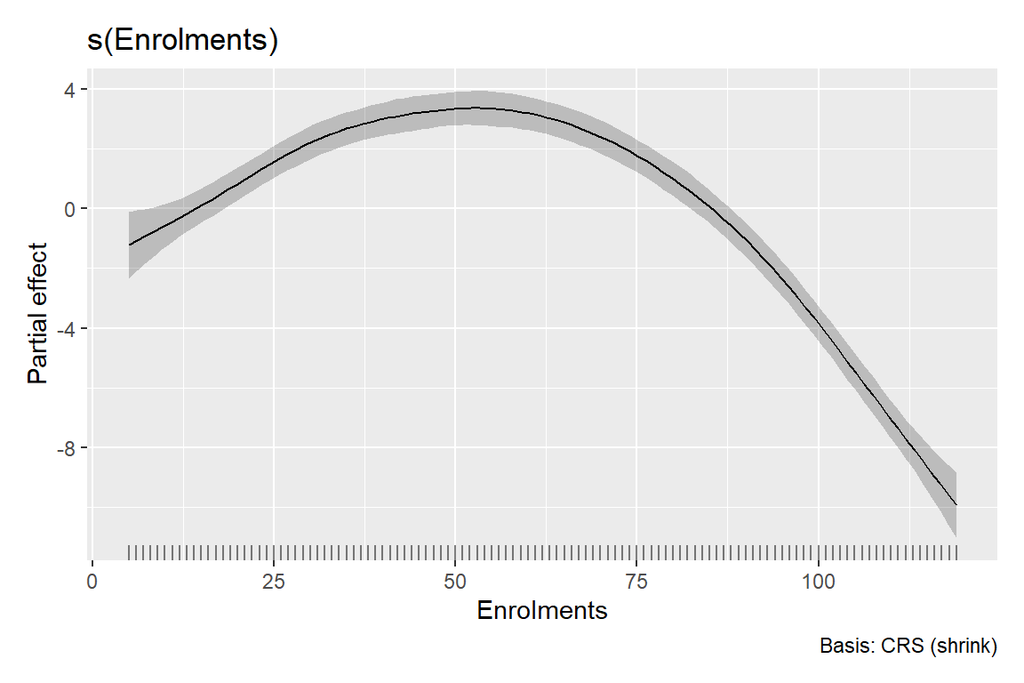

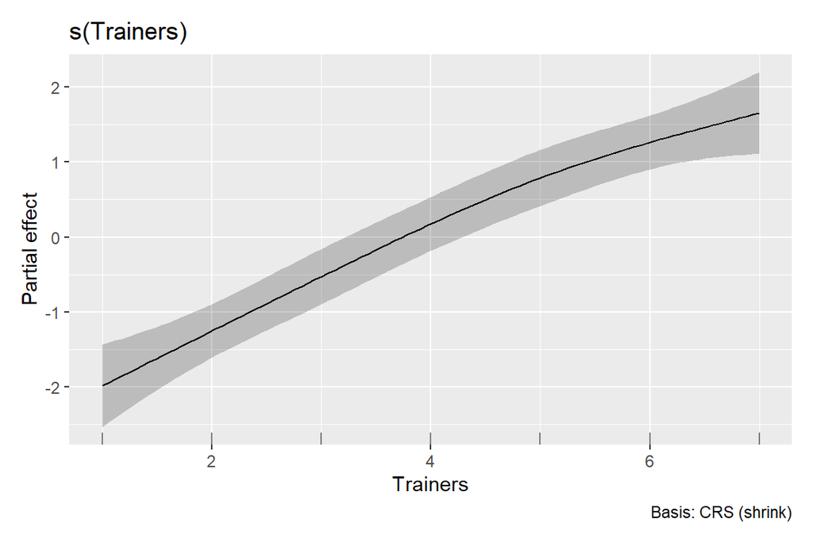

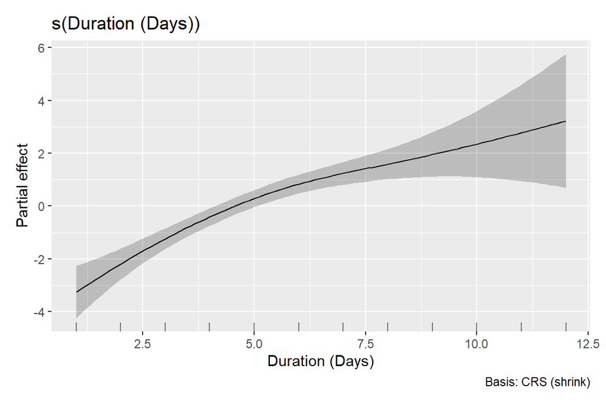

# Diagnostic Plots

**Manual Raw Residuals and Observed vs Predicted Plots**

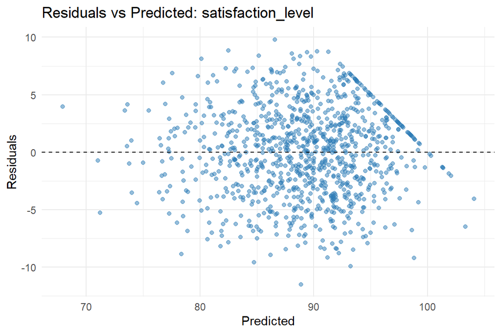

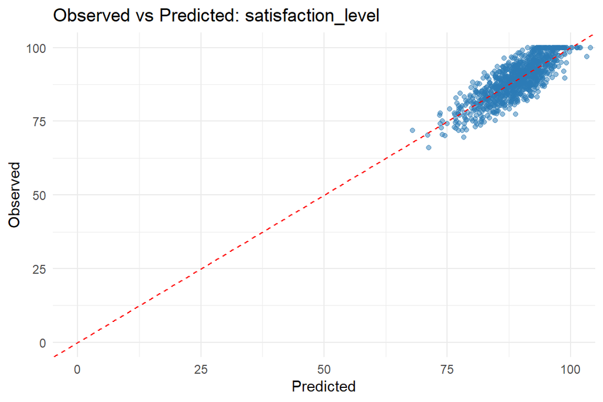

**GAM Diagnostics (gratia::appraise)**

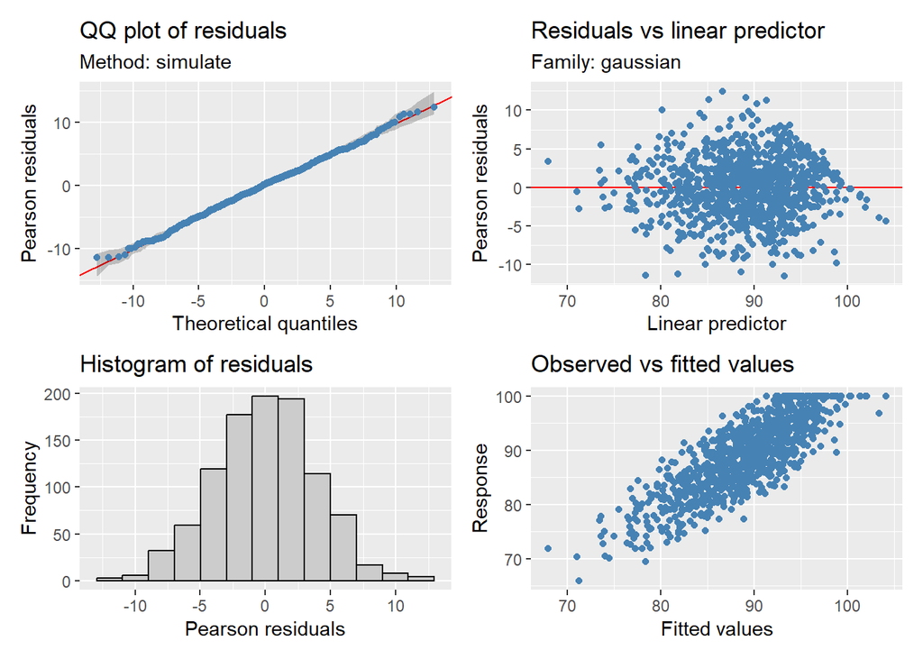

# Multicollinearity Diagnostics

**GVIF Diagnostics**

GVIF and Adjusted GVIF for Parametric Terms

| Term | GVIF | Df | GVIF_adj |
| --- | --- | --- | --- |
| session_delivery | 1.04 | 2 | 1.01 |
| session_framework | 1.05 | 2 | 1.01 |
| session_organiser | 1.06 | 3 | 1.01 |
| session_language | 1.04 | 2 | 1.01 |
| modules_topic | 1.06 | 3 | 1.01 |
| level | 1.03 | 2 | 1.01 |
| year | 1.08 | 5 | 1.01 |

**Concurvity / VIF for Smooth Terms**

Note: Adjusted GVIFs account for the number of parameters in each term, making them comparable across terms with different degrees of freedom.  
For smooth terms, the worst-case concurvity shows the maximum dependence of one smooth on the others.

Worst-case concurvity diagnostics

| Term | para | s(enrolments) | s(trainers) | s(duration_days) |
| --- | --- | --- | --- | --- |
| para | 1.00e+00 | 4.19e-31 | 4.20e-31 | 3.41e-30 |
| s(enrolments) | 4.12e-31 | 1.00e+00 | 9.18e-03 | 1.30e-02 |
| s(trainers) | 4.94e-31 | 9.18e-03 | 1.00e+00 | 1.84e-02 |
| s(duration_days) | 4.37e-30 | 1.30e-02 | 1.84e-02 | 1.00e+00 |